# 二元配置分散分析

### 多重比較

まず、SoilとFertilizerをつなげ、すべての試験区を区別できる新しい因子SoilFertを作る。

```r
kadai1$SoilFert <- as.factor(paste(kadai1$Soil,kadai1$Fertilizer,sep=""))
summary(kadai1)
```

```
##     Soil    Fertilizer     Yield            SoilFert
##  SoilA:12   N100:6     Min.   :14.10   SoilAN100:3
##  SoilB:12   N200:6     1st Qu.:15.90   SoilAN200:3
##             N300:6     Median :17.65   SoilAN300:3
##             N400:6     Mean   :18.23   SoilAN400:3
##                        3rd Qu.:19.60   SoilBN100:3
##                        Max.   :25.50   SoilBN200:3
##                                        (Other)  :6
```

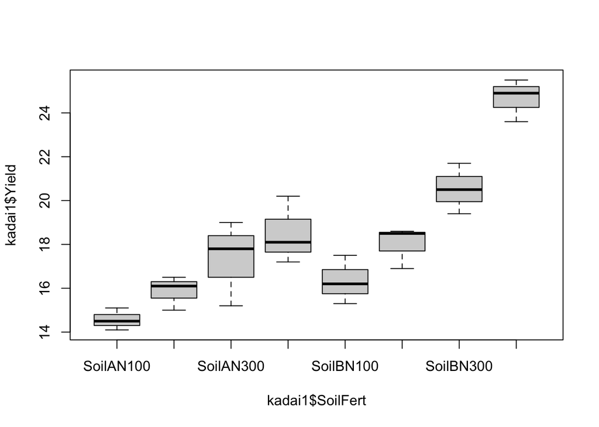

```r
boxplot(kadai1$Yield~kadai1$SoilFert)
```

なんとなく傾向がわかった。  
念のため一元配置分散分析を行っておく。有意になるはず。

```r
summary(aov(kadai1$Yield~kadai1$SoilFert))
```

```
##                 Df Sum Sq Mean Sq F value   Pr(>F)
## kadai1$SoilFert  7  210.8  30.115   21.13 5.83e-07 ***
## Residuals       16   22.8   1.425
## ---
## Signif. codes:  0 '***' 0.001 '**' 0.01 '*' 0.05 '.' 0.1 ' ' 1
```

多重比較にはTukey-Kramer法を`multcomp`ライブラリーで行った。

（wariningがでると思いますが良しとします。）

```r
library(multcomp)
result1 <- aov(Yield~SoilFert,data=kadai1) # 分散分析の結果をresult1に格納
summary(result1) # 結果を表示する
```

```
##             Df Sum Sq Mean Sq F value   Pr(>F)
## SoilFert     7  210.8  30.115   21.13 5.83e-07 ***
## Residuals   16   22.8   1.425
## ---
## Signif. codes:  0 '***' 0.001 '**' 0.01 '*' 0.05 '.' 0.1 ' ' 1
```

```r
result2 <- glht(result1, linfct = mcp(SoilFert = "Tukey")) # Tukey-Kramerの結果をresult2に格納
summary(result2) # 結果を表示する
```

```
##
##   Simultaneous Tests for General Linear Hypotheses
##
## Multiple Comparisons of Means: Tukey Contrasts
##
##
## Fit: aov(formula = Yield ~ SoilFert, data = kadai1)
##
## Linear Hypotheses:
##                            Estimate Std. Error t value Pr(>|t|)
## SoilAN200 - SoilAN100 == 0   1.3000     0.9747   1.334  0.87293
## SoilAN300 - SoilAN100 == 0   2.7667     0.9747   2.839  0.15274
## SoilAN400 - SoilAN100 == 0   3.9333     0.9747   4.036  0.01672 *
## SoilBN100 - SoilAN100 == 0   1.7667     0.9747   1.813  0.62133
## SoilBN200 - SoilAN100 == 0   3.4333     0.9747   3.523  0.04465 *
## SoilBN300 - SoilAN100 == 0   5.9667     0.9747   6.122  < 0.001 ***
## SoilBN400 - SoilAN100 == 0  10.1000     0.9747  10.362  < 0.001 ***
## SoilAN300 - SoilAN200 == 0   1.4667     0.9747   1.505  0.79467
## SoilAN400 - SoilAN200 == 0   2.6333     0.9747   2.702  0.19115
## SoilBN100 - SoilAN200 == 0   0.4667     0.9747   0.479  0.99962
## SoilBN200 - SoilAN200 == 0   2.1333     0.9747   2.189  0.40605
## SoilBN300 - SoilAN200 == 0   4.6667     0.9747   4.788  0.00383 **
## SoilBN400 - SoilAN200 == 0   8.8000     0.9747   9.029  < 0.001 ***
## SoilAN400 - SoilAN300 == 0   1.1667     0.9747   1.197  0.92142
## SoilBN100 - SoilAN300 == 0  -1.0000     0.9747  -1.026  0.96320
## SoilBN200 - SoilAN300 == 0   0.6667     0.9747   0.684  0.99633
## SoilBN300 - SoilAN300 == 0   3.2000     0.9747   3.283  0.06941 .
## SoilBN400 - SoilAN300 == 0   7.3333     0.9747   7.524  < 0.001 ***
## SoilBN100 - SoilAN400 == 0  -2.1667     0.9747  -2.223  0.38857
## SoilBN200 - SoilAN400 == 0  -0.5000     0.9747  -0.513  0.99940
## SoilBN300 - SoilAN400 == 0   2.0333     0.9747   2.086  0.46166
## SoilBN400 - SoilAN400 == 0   6.1667     0.9747   6.327  < 0.001 ***
## SoilBN200 - SoilBN100 == 0   1.6667     0.9747   1.710  0.68166
## SoilBN300 - SoilBN100 == 0   4.2000     0.9747   4.309  0.00960 **
## SoilBN400 - SoilBN100 == 0   8.3333     0.9747   8.550  < 0.001 ***
## SoilBN300 - SoilBN200 == 0   2.5333     0.9747   2.599  0.22554
## SoilBN400 - SoilBN200 == 0   6.6667     0.9747   6.840  < 0.001 ***
## SoilBN400 - SoilBN300 == 0   4.1333     0.9747   4.241  0.01136 *
## ---
## Signif. codes:  0 '***' 0.001 '**' 0.01 '*' 0.05 '.' 0.1 ' ' 1
## (Adjusted p values reported -- single-step method)
```

```r
cld(result2) # compact letter displayで多重比較の結果を表示
```

```
## SoilAN100 SoilAN200 SoilAN300 SoilAN400 SoilBN100 SoilBN200 SoilBN300 SoilBN400
##       "a"      "ab"      "ac"      "bc"      "ab"      "bc"       "c"       "d"
```

Compact letter displayをつけてグラフを描く。

```r
par()$mar # 上が切れるのでマージンを確認（私の場合は5.1 4.1 4.1 2.1）
```

```
## [1] 5.1 4.1 4.1 2.1
```

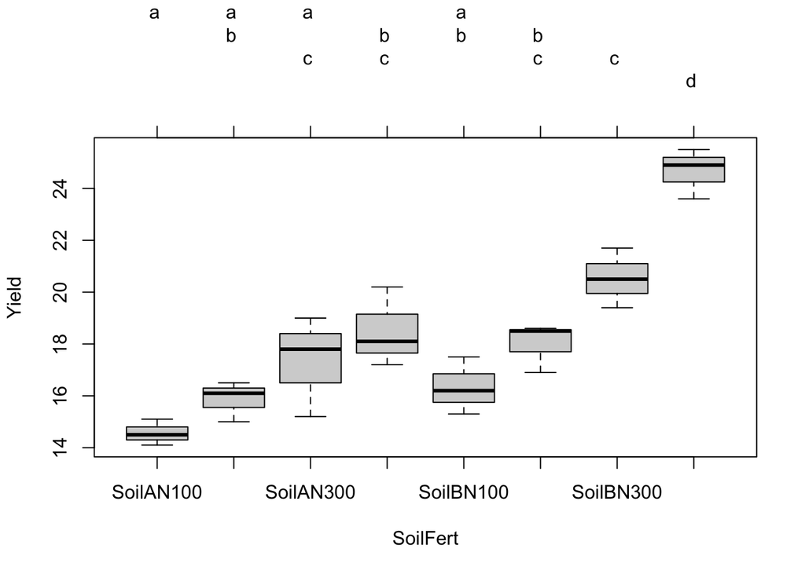

```r
par(mar=c(5.1, 4.1, 6, 2.1)) # 上のマージンを広げる
plot(cld(result2)) # compact letter displayつきの箱ひげ図を描く
```

（異なる文字のグループの間では5%水準で有意な差があることを示す。）

（課題1はここまで）